# Titanic Data Visualization:

## Summary:

> Data visualization story of titanic incident created using tableau. The tableau story shows a multiple graphs representing the passengers data like thier ages and classes and so on. With these graphs we may find intresting thoughts like the chance of surviving or being dead which draws conclusion that female of first class had higher chances of survival and males of third class had least chances of survival. In general, females had higher chances of survival than males.

## Design:

#### let's start with the story part by part:

> - "All passengers from the selected sample": at this dashboard I choosed two types of charts to represent the passengers were in board, the first one was only marks each one represent one passenger, and the secound one is a table which give a first look to the sample data.

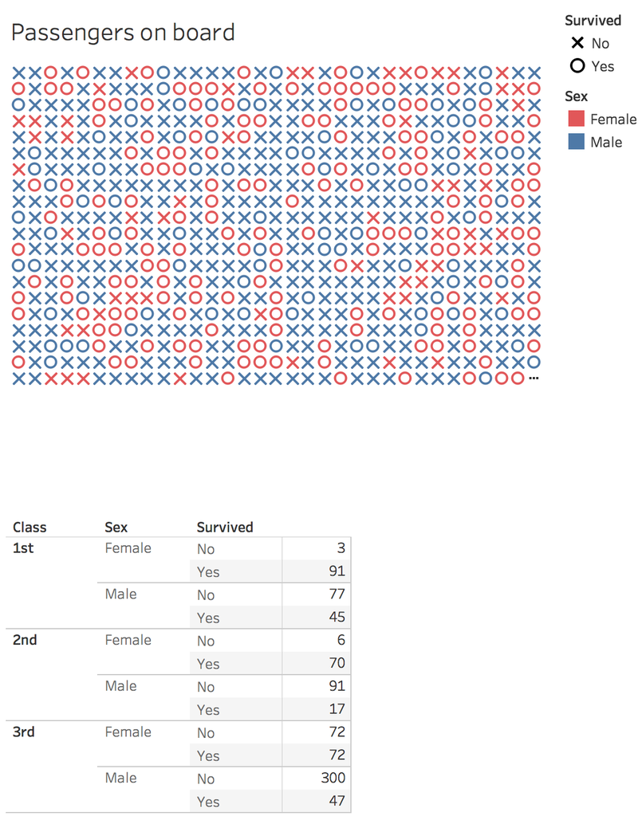

```python
from IPython.display import Image
Image("/Users/Abdulaziz/Desktop/p1.png", width ="300")
```

> - "Passengers ages": At this chart I choosed column type to show the distribution of age for the passengers with showing the state of surviving and we can see that most of passengers were from 20 - 30 years old.

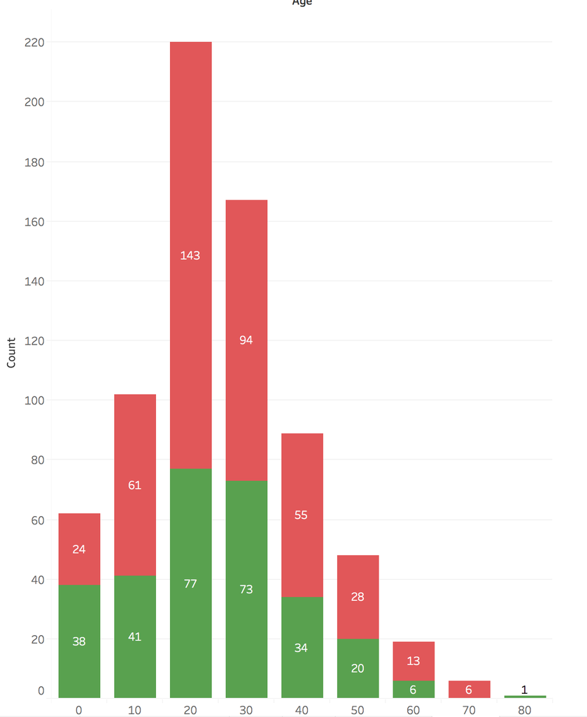

```python
from IPython.display import Image
Image("/Users/Abdulaziz/Desktop/p2.png", width ="300")
```

> - "Average age of passengers based on sex and passenger class": At this chart I choosed column type with double charts to visualize the data which is the average age of passengers based on their sex and class on the top part and the bottom part is the same thing but without dividing the data by sex.

```python
from IPython.display import Image
Image("/Users/Abdulaziz/Desktop/p3.png", width ="100")
```

[output not shown]

> - "Passengers avg fare over the starting point of titianic trip": This chart (Bubble) represent the average fare for the passengers and the count with showing the chart as three parts for each starting point and at the bottom same thing but with specifying the passenger class.

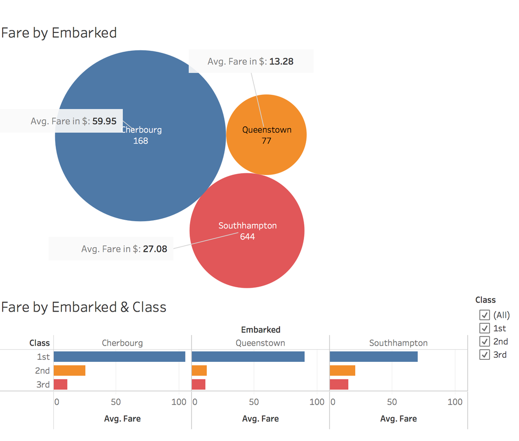

```python
from IPython.display import Image
Image("/Users/Abdulaziz/Desktop/p4.png", width ="300")
```

> - "Count of all passengers with keeping in mind the surviving and the passenger class": For this chart I'm using bar type to represent the count of all passengers of the selected sample with based on the class and the surviving status.

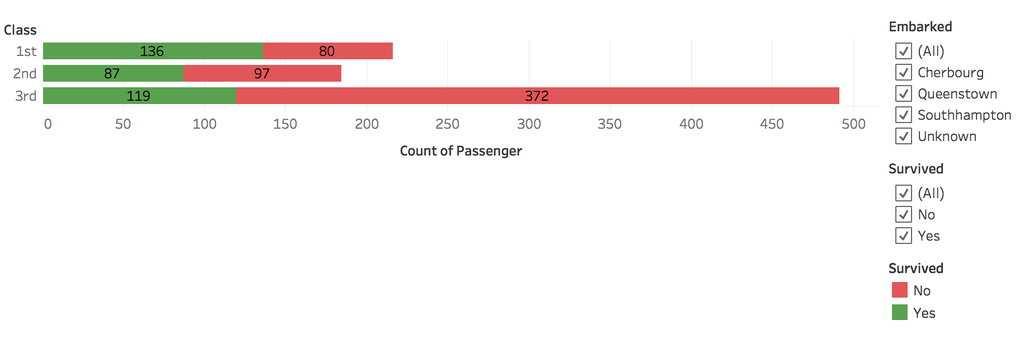

```python
from IPython.display import Image
Image("/Users/Abdulaziz/Desktop/p5.png", width ="500")
```

#### Note: all dashboads on the sotry have a filter and labels, the images above just a peek.

> The story URL (before feedback): https://public.tableau.com/profile/abdulaziz5265#!/vizhome/TitanicTableauStory/Story1

## Feedback:

> 1- What do you notice in the visualization?

> I see most dead people is men and from the 3rd class.

> 2- What questions do you have about the data?

> There is a few people in this data, where is the rest of them?

> 3- What relationships do you notice?

> if I'm a woman in the 1st class I'll have a better chance to survive.

> 4- Is there something you don’t understand in the graphic?

> Yes actually there are many things:
> - In the secound part of the story at "Passengers Ages"the ages is not clear to me at the bottom of the chart.
> - The value of each column is not specified at "Passengers Ages" like others charts.
> - In the 4th part of the story, I think it's better if there is a count of passengers including the avg fare for each location.

## Process Feedback:

> In the 1st and 3rd questions, I got a good feedback and there is nothing to add.

> Final Titanic Story URL (After Feedback): https://public.tableau.com/profile/abdulaziz5265#!/vizhome/TitanicTableauStory-afterfeedback/Story1

## Resources:

> - https://github.com/
> - https://public.tableau.com/
> - https://classroom.udacity.com/